# Yapay zeka, Makine Öğrenmesi, Veri Maaşları

Halil Görkem Herek

Bu çalışma Shiny framework’ü kullanarak Yapay zeka, Makine Öğrenmesi, Veri Maaşları ile ilgili interaktif web uygulaması oluşturmaktadır. Bu uygulama, çalışma deneyimi, istihdam türü, uzaktan çalışma oranı ve şirket büyüklüğü gibi filtrelerle veri setini filtreleyen ve çeşitli grafikler ve tablolarla sonuçları gösteren bir arayüze sahiptir.

Bu Shiny uygulamasında salaries.csv adlı veri seti kullanılmıştır. Bu veri seti 2020-2023 yılları arasında dünya çapında AI, ML ve Data’daki maaş eğilimlerini göstermektedir. Toplamda 11 sütun ve 4134 adet kayıttan oluşmaktadır. Sütun anlamları:

- **work_year :** Maaşın ödendiği yıl
- **experience_level :** Yıl boyunca işteki deneyim düzeyi
  - EN : Giriş Seviyesi
  - MI : Çaylak Orta seviye
  - SE : Orta seviye Kıdemli seviyesi
  - EX : Uzman Yönetici düzeyinde / Direktör
- **employment_type :** Rol için istihdam türü
  - PT : Yarı zamanlı
  - FT : Tam zamanlı
  - CT : Sözleşmeli
  - FL : Serbest
- **job_title :** Yıl boyunca çalışılan rol.
- **salary :** Ödenen toplam brüt maaş tutarı.
- **salary_currency :** ISO 4217 para birimi kodu olarak ödenen maaşın para birimi.
- **sallary_in_usd :** USD cinsinden maaş ( fxdata.foorilla.com üzerinden ilgili yıl için döviz kurunun ort. USD kuruna bölümü .
- **employee__residence :** ISO 3166 ülke kodu olarak çalışanın çalışma yılı boyunca birincil ikamet ettiği ülke
- **remote_ratio :** Uzaktan yapılan toplam iş miktarı
  - 0 : Uzaktan çalışma yok (%20’den az)
  - 50 : Kısmen uzak (Hibrit)
  - 100 : Tamamen uzak (Remote)(%80’den fazla)
- **company_location :** ISO 3166 ülke kodu olarak işverenin ana ofisi veya sözleşmeli şubesinin bulunduğu ülke.
- **company_size :** Yıl boyunca şirket için çalışan ortalama kişi sayısı
  - S : 50’den az çalışan (küçük)
  - M : 50 ila 250 çalışan (orta)
  - L : 250’den fazla çalışan (büyük)

```r
head(salaries)
```

```
##   work_year experience_level employment_type          job_title salary
## 1      2023               MI              FT AWS Data Architect 258000
## 2      2023               SE              FT     Data Scientist 225000
## 3      2023               SE              FT     Data Scientist 156400
## 4      2023               SE              FT      Data Engineer 190000
## 5      2023               SE              FT      Data Engineer 150000
## 6      2023               SE              FT     Data Scientist 196000
##   salary_currency salary_in_usd employee_residence remote_ratio
## 1             USD        258000                 US          100
## 2             USD        225000                 US            0
## 3             USD        156400                 US            0
## 4             USD        190000                 US          100
## 5             USD        150000                 US          100
## 6             USD        196000                 US            0
##   company_location company_size
## 1               US            L
## 2               US            M
## 3               US            M
## 4               US            M
## 5               US            M
## 6               US            M
```

Salaries verisetinin istatistiksel özetine göz atalım:

```r
summary(salaries)
```

```
##    work_year    experience_level   employment_type     job_title
##  Min.   :2020   Length:4134        Length:4134        Length:4134
##  1st Qu.:2022   Class :character   Class :character   Class :character
##  Median :2023   Mode  :character   Mode  :character   Mode  :character
##  Mean   :2022
##  3rd Qu.:2023
##  Max.   :2023
##      salary         salary_currency    salary_in_usd    employee_residence
##  Min.   :    6000   Length:4134        Min.   :  5132   Length:4134
##  1st Qu.:  100000   Class :character   1st Qu.: 96817   Class :character
##  Median :  140000   Mode  :character   Median :136000   Mode  :character
##  Mean   :  189429                      Mean   :139416
##  3rd Qu.:  183310                      3rd Qu.:179820
##  Max.   :30400000                      Max.   :450000
##   remote_ratio    company_location   company_size
##  Min.   :  0.00   Length:4134        Length:4134
##  1st Qu.:  0.00   Class :character   Class :character
##  Median :  0.00   Mode  :character   Mode  :character
##  Mean   : 45.94
##  3rd Qu.:100.00
##  Max.   :100.00
```

Histogramda kullanılan çubukların genişliğini veri setimizin dağılımına göre ‘binwidth’ değerimizi hesaplayalım.

```r
IQR <- quantile(salaries$salary_in_usd, 0.75) - quantile(salaries$salary_in_usd, 0.25)
n <- length(salaries$salary_in_usd)
binwidth <- 2 * IQR / (n^(1/3))
```

Çizilen grafik ‘salary_in_usd’ sütunundaki maaş değerlerinin dağılımını göstermektedir.

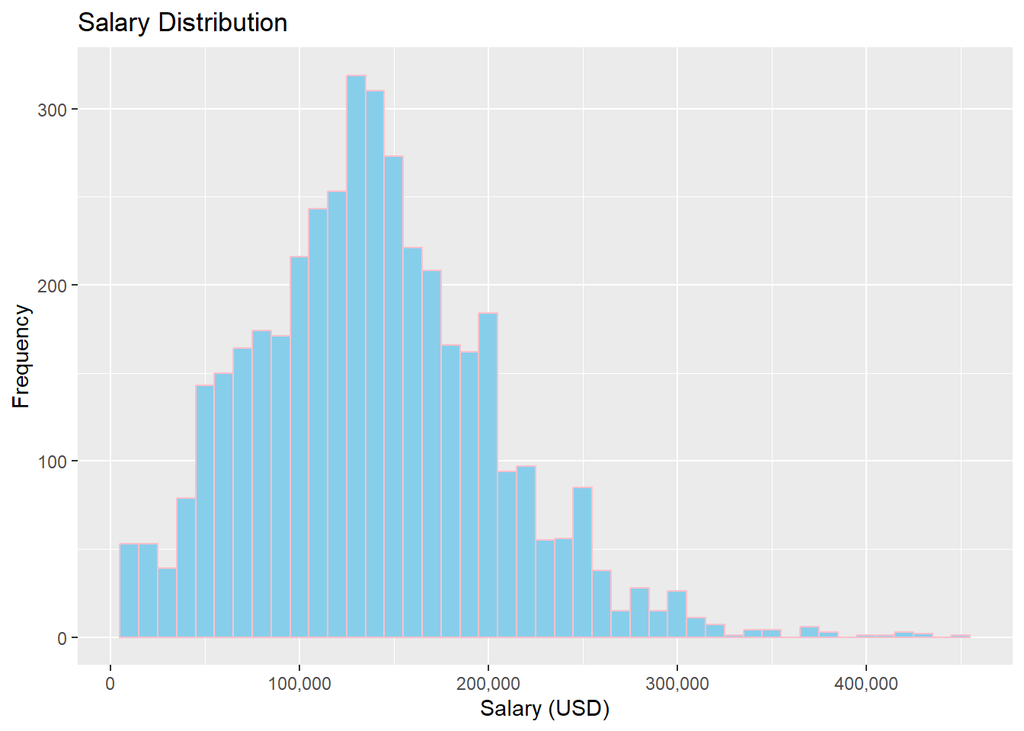

```r
ggplot(salaries, aes(x = salary_in_usd)) +
  geom_histogram(binwidth = 10000, fill = "skyblue", color = "pink") +
  scale_x_continuous(labels = scales::comma) +
  labs(title = "Salary Distribution", x = "Salary (USD)", y = "Frequency")
```

Başlıca önde gelen mesleklerin maaş dağılımları

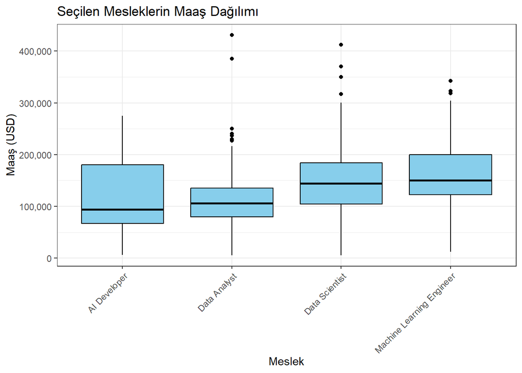

```r
selected_jobs <- c("Data Scientist", "Data Analyst", "Machine Learning Engineer", "AI Developer")
filtered_data <- subset(salaries, job_title %in% selected_jobs)

ggplot(filtered_data, aes(x = job_title, y = salary_in_usd)) +
  geom_boxplot(fill = "skyblue", color = "black") +
  xlab("Meslek") +
  ylab("Maaş (USD)") +
  ggtitle("Seçilen Mesleklerin Maaş Dağılımı") +
  theme_bw() +
  scale_y_continuous(labels = scales::comma) +
  theme(axis.text.x = element_text(angle = 45, hjust = 1))
```

## Referanslar:

[Salaries Veri Seti](https://www.kaggle.com/datasets/nguyenthicamlai/ai-ml-data-salaries): Kaggle’dan [NGUYEN THI CAM LAI](https://www.kaggle.com/nguyenthicamlai) adlı kullanıcıdan alınmıştır.